# Estimación paramétrica y no paramétrica

Roman

23/3/2020

```r
#load library
library(survival)
library(survminer)
library(reshape)
```

# Estimar parametricamente *survreg*.

Este comando escribe los parámetros a estimar como localización y escala, $a,b$ y los estima. Además ajusta un objeto de supervivencia. Lo haremos para las distribuciones:

- Weibull
- Log-Logistic
- Log-Normal

**Datos del trabajo**.

```r
#read data
df_r <- read.csv('C:/Users/Ryo/Documents/Enso/BDD/Sales/2020-04-25analysisSellers.csv')
# times
df_activation <- data.frame(time = df_r$diff_time_activation + 0.1, delta = df_r$censor_activated, seller = df_r$phone_seller_enso)


#EMV con comando survreg
xfitp<-survreg(Surv(time = time,event = delta) ~ 1,dist="weibull", data = df_activation)

#summary and structure
summary(xfitp)
```

```
##
## Call:
## survreg(formula = Surv(time = time, event = delta) ~ 1, data = df_activation,
##     dist = "weibull")
##              Value Std. Error     z       p
## (Intercept) 3.2765     0.1070 30.62 < 2e-16
## Log(scale)  0.4328     0.0613  7.06 1.7e-12
##
## Scale= 1.54
##
## Weibull distribution
## Loglik(model)= -860.2   Loglik(intercept only)= -860.2
## Number of Newton-Raphson Iterations: 6
## n= 291
```

```r
#coefficients
as<-xfitp$coefficients
bs<-xfitp$scale
#return coeffs from loc-scale to loc-rate CHECAR!
alf<-1/bs
lam<-exp(-as/bs)
a<-alf
b<-lam^(-1/alf)
```

Otras distribuciones

```r
 #MODIFICAR
#
# xfitp<-survreg(t~1,dist="loglogistic")
# summary(xfitp)
# #
# xfitp<-survreg(t~1,dist="lognormal")
# summary(xfitp)
```

# Estimación No paramétrica

# Ejemplo: Vida billetes BANXICO

Datos sin censura. Son el tiempo de **vida** de los *billetes de doscientes de Banxico*. Como no hay censura en los datos, se puede hacer un *EDA* sin problemas. Crear el *objeto* de supervivencia en R.

```r
bill<-read.table("http://allman.rhon.itam.mx/~lnieto/index_archivos/Billete200.txt",header=TRUE)

#summary
summary(bill$Vida)
```

```
##    Min. 1st Qu.  Median    Mean 3rd Qu.    Max.
## 0.00334 1.76367 2.34489 2.52305 3.02630 8.00000
```

Kaplan-Meyer estimator

```r
#KM estimator
xfit<-survfit(Surv(Vida,Consecutivo/Consecutivo)~1, data = bill)

#look estimator
print(xfit)
```

```
## Call: survfit(formula = Surv(Vida, Consecutivo/Consecutivo) ~ 1, data = bill)
##
##        n   events   median  0.95LCL  0.95UCL
## 23585.00 23585.00     2.34     2.33     2.36
```

# Estimadores paramétricos.

## CUM-HAZARD

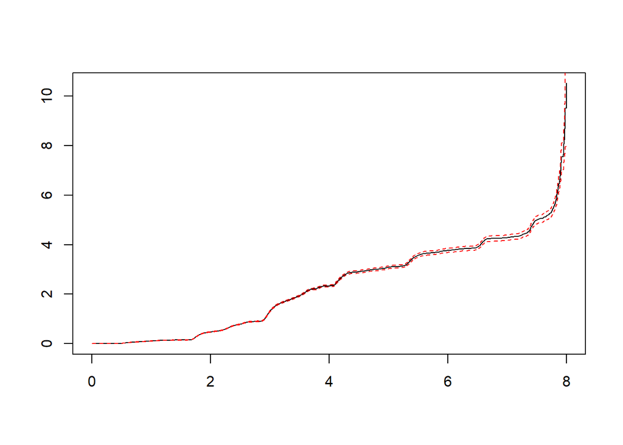

```r
#plot
plot(xfit,fun="cumhaz",col=c(1,2,2))
```

Extracción

```r
#-Extraccion de tiempos de fallo y supervivencia-
tj<-xfit$time #exact time
sj<-xfit$surv #survivance at tj time
k<-length(tj)
sje<-0.5*sj+0.5*c(1,sj[-k]) #correcion por continuidad
```

Resúmenes

```r
#Mediana (dentro del comando survfit)
#Media
mean(t) #lo da "mal"
```

```
## [1] NA
```

```r
tj2<-c(0,tj[-k])
sj2<-c(1,sj[-k])

#crude integral (area below curve)
means<-sum((tj-tj2)*sj2)

#compare
print(means)
```

```
## [1] 2.523051
```

Romper media con “trimmed” values

```r
trimed = c(6)
print(xfit,rmean=trimed)
```

```
## Call: survfit(formula = Surv(Vida, Consecutivo/Consecutivo) ~ 1, data = bill)
##
##          n     events     *rmean *se(rmean)     median    0.95LCL
##   2.36e+04   2.36e+04   2.50e+00   7.49e-03   2.34e+00   2.33e+00
##    0.95UCL
##   2.36e+00
##     * restricted mean with upper limit =  6
```

¿Que pasa si lo comparamos con modelos paramétricos?

La teoría dice que si un modelo paramétrico es adecuado, entonces $S(t|) $ y $\hat{S}_{KM}(t)$ deben ser muy parecidos.

Verificaciones para ver si se ajustan a un modelo Weibull, exponencial o Log-Logistico.

### Supuesto exponencial

- $ln(S(t)) = - \lambda t$

No debería de haber intercepto

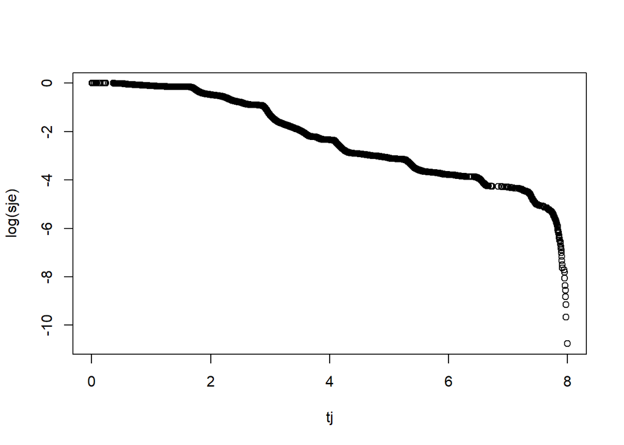

```r
#-Verificacin de supuesto exponencial-
plot(tj,log(sje))
```

### Caso weibull

- $ln( - ln(S(t))) = ln( \lambda t ) + \alpha ln(t)$

Queremos una grafica lineal con intercepto

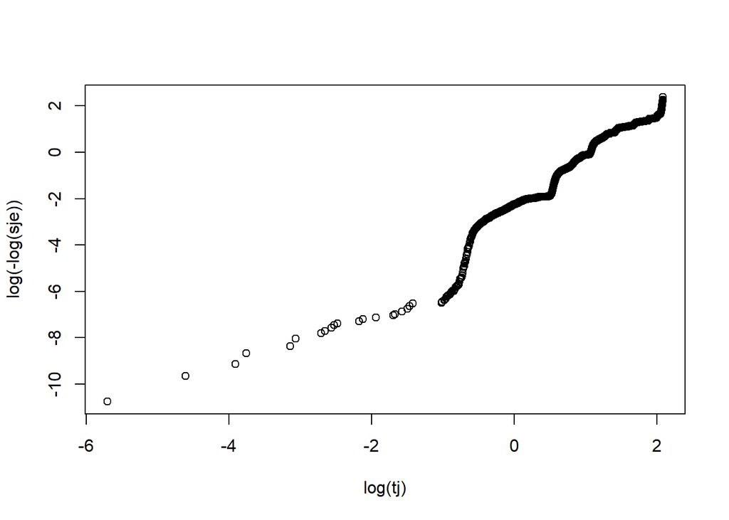

```r
#-Verificacin de supuesto weibull-
plot(log(tj),log(-log(sje)))
```

### Lognormal

- QQ-plot para $ln(t)$ debería de presentar un comportamiento casi lineal

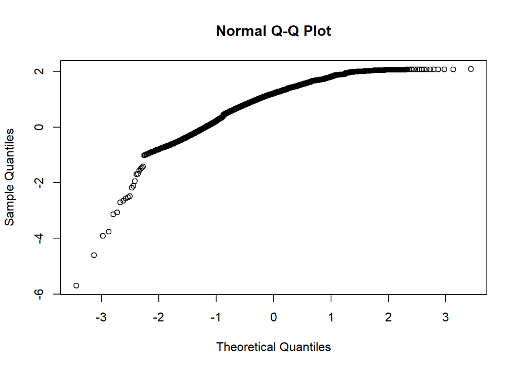

```r
#-Verificacin de supuesto lognormal-
qqnorm(log(tj))
```

El que mejor se ajusta es el Weibull, pero comparémoslo contra el estimador Kaplan-Meyer

## Weibull

El que mejor se ajusta es el Weibull, pero comparémoslo contra el estimador Kaplan-Meyer. *Graficamos* modelos parametricos. *A la Nieto*.

- *Verde*: Parametrico
- *Negro*: Kaplan-Meier

```r
#-Weibull-
#Ajuste
xfitp<-survreg(Surv(Vida,Consecutivo/Consecutivo)~1, data = bill, dist="weibull")
summary(xfitp)
```

```
##
## Call:
## survreg(formula = Surv(Vida, Consecutivo/Consecutivo) ~ 1, data = bill,
##     dist = "weibull")
##                Value Std. Error    z      p
## (Intercept)  1.04676    0.00324  324 <2e-16
## Log(scale)  -0.75401    0.00474 -159 <2e-16
##
## Scale= 0.47
##
## Weibull distribution
## Loglik(model)= -37152.9   Loglik(intercept only)= -37152.9
## Number of Newton-Raphson Iterations: 6
## n= 23585
```

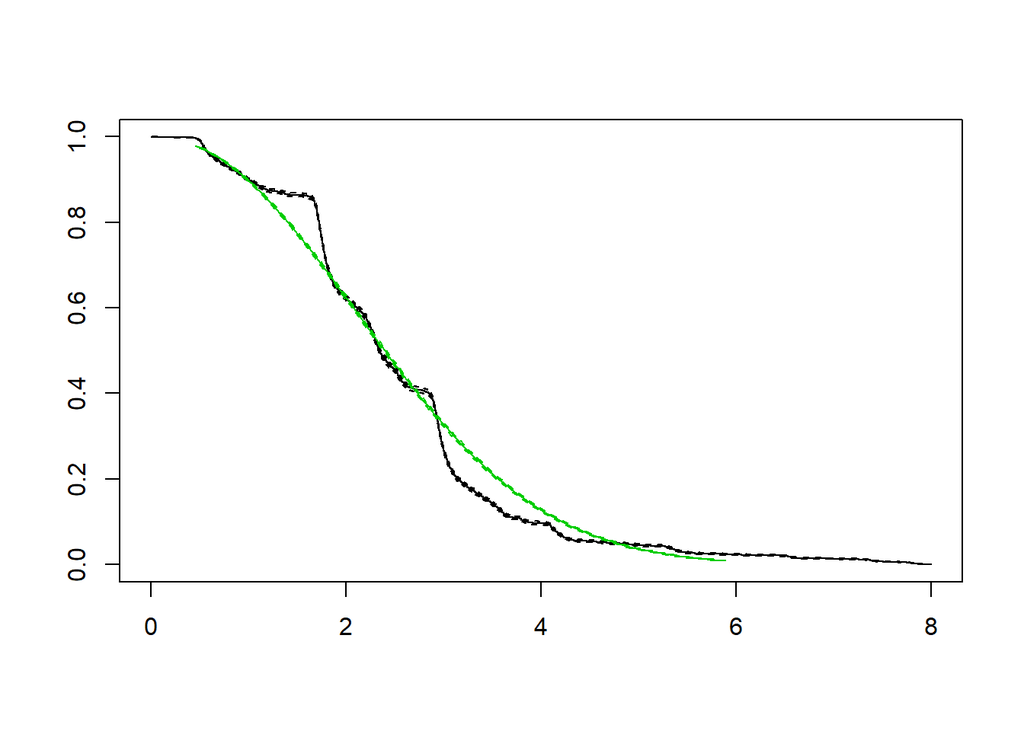

```r
#Prediccion
pct<-1:98/100
xpredp<-predict(xfitp,type="quantile",p=1-pct,se=TRUE)
plot(xfit) #kaplan-meier
#weibull
lines(xpredp$fit[1,],pct,col=3)
#confidence intervals
lines(xpredp$fit[1,]-2*xpredp$se.fit[1,],pct,col=3,lty=2)
lines(xpredp$fit[1,]+2*xpredp$se.fit[1,],pct,col=3,lty=2)
```

Graficamos con *ggsurvplot_df* ahora.

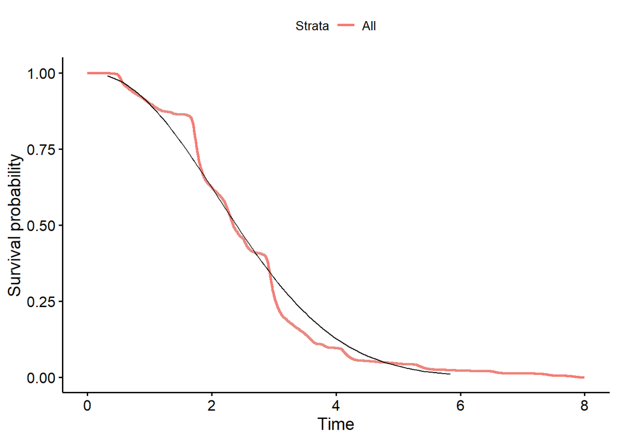

```r
#cuantiles
p <- seq(0.99, 0.01,by = -0.01)

#predict
pred <- predict(xfitp, type = 'quantile', p = 1-p, newdata = bill[1,])

#create data.frame with the survival curve info
out_wb <- data.frame(time = pred, surv = p, upper = NA, lower = NA, std.err = NA)


#graph
#parametric
g_wb <- ggsurvplot_df(out_wb, surv.geom = geom_line, conf.int = FALSE)

#km
g_km <- ggsurvplot(xfit, conf.int = TRUE)

#compare both graphs
g_km$plot + geom_line(data = out_wb, aes(x = time, y = surv))
```

Observamos que para los modelos que no tienen covariables, es más complicado usar *ggsurvplot_df*. Al estilo Nieto es mejor.

Veamos las otras distribuciones

Caso log-normal

```r
#-Lognormal-
#Ajuste
xfitp<-survreg(Surv(Vida,Consecutivo/Consecutivo)~1, data = bill, dist="lognormal")
summary(xfitp)
```

```
##
## Call:
## survreg(formula = Surv(Vida, Consecutivo/Consecutivo) ~ 1, data = bill,
##     dist = "lognormal")
##                Value Std. Error    z      p
## (Intercept)  0.79574    0.00357  223 <2e-16
## Log(scale)  -0.59962    0.00460 -130 <2e-16
##
## Scale= 0.549
##
## Log Normal distribution
## Loglik(model)= -38091.1   Loglik(intercept only)= -38091.1
## Number of Newton-Raphson Iterations: 5
## n= 23585
```

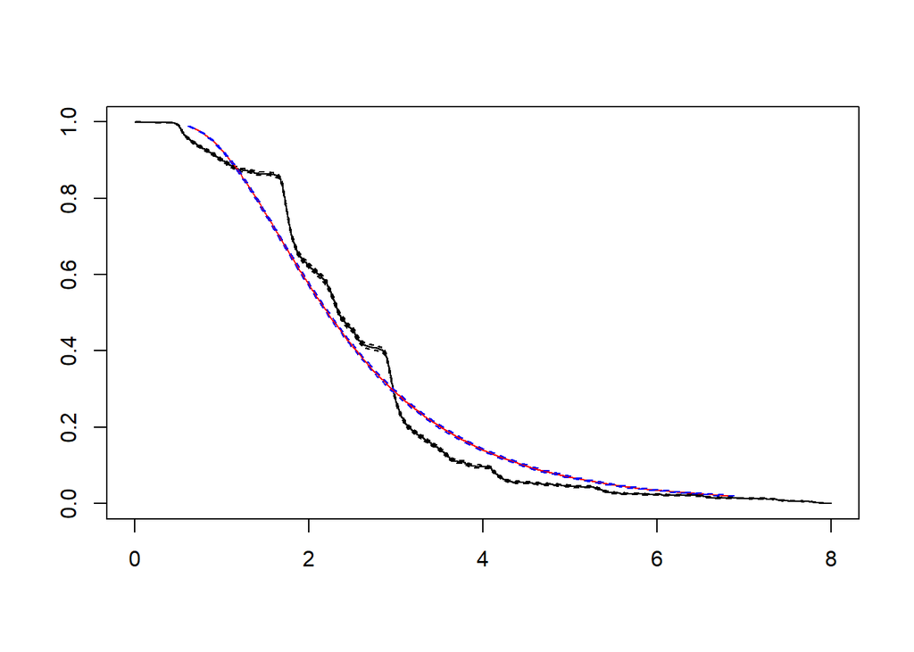

```r
#Prediccion
xpredp<-predict(xfitp)
pct <- 1:98/100
xpredp<-predict(xfitp,type="quantile",p=pct, se=TRUE)
plot(xfit)
lines(xpredp$fit[1,],1-pct,col=2)
lines(xpredp$fit[1,]-2*xpredp$se.fit[1,],1-pct,col=4,lty=2)
lines(xpredp$fit[1,]+2*xpredp$se.fit[1,],1-pct,col=4,lty=2)
```

Caso loglogistico

```r
#-Loglogistico-
#Ajuste
xfitp<-survreg(Surv(Vida,Consecutivo/Consecutivo)~1, data = bill, dist="loglogistic")
summary(xfitp)
```

```
##
## Call:
## survreg(formula = Surv(Vida, Consecutivo/Consecutivo) ~ 1, data = bill,
##     dist = "loglogistic")
##                Value Std. Error    z      p
## (Intercept)  0.84202    0.00318  264 <2e-16
## Log(scale)  -1.24887    0.00556 -225 <2e-16
##
## Scale= 0.287
##
## Log logistic distribution
## Loglik(model)= -37015.5   Loglik(intercept only)= -37015.5
## Number of Newton-Raphson Iterations: 6
## n= 23585
```

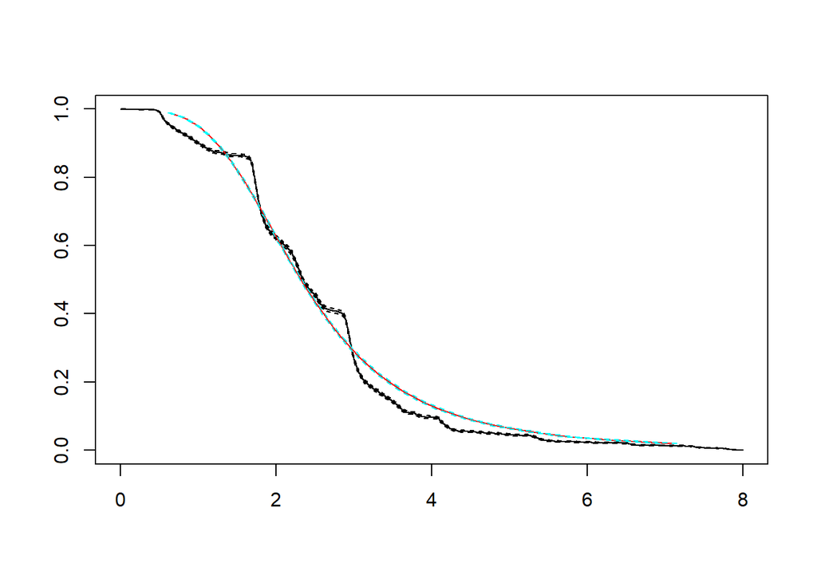

```r
#Prediccion
xpredp<-predict(xfitp)
pct <- 1:98/100
xpredp<-predict(xfitp,type="quantile",p=pct,se=TRUE)
plot(xfit)
lines(xpredp$fit[1,],1-pct,col=2)
lines(xpredp$fit[1,]-2*xpredp$se.fit[1,],1-pct,col=5,lty=2)
lines(xpredp$fit[1,]+2*xpredp$se.fit[1,],1-pct,col=5,lty=2)
```